# Umeå Software Carpentry

9-10th October 2018

Etherpad: https://pad.carpentries.org/2018-10-09-umea

Gapminder: https://raw.githubusercontent.com/swcarpentry/r-novice-gapminder/gh-pages/_episodes_rmd/data/gapminder_data.csv

## The Carpentries

"…teaching researchers the computing skills they need to get more done in less time and with less pain. "

## Code of conduct

"We are committed to creating a friendly and respectful place for learning, teaching and contributing. All participants in our events and communications are expected to show respect and courtesy to others."

- Alistair Bailey
- website: ab604.uk
- email: ab604@soton.ac.uk
- twitter: @alistair604

[figure not shown]

[figure not shown]

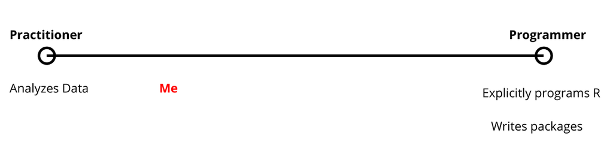

Ross Ihaka and Robert Gentleman.

R: A language for data analysis and graphics. Journal of Computational and Graphical Statistics, 5(3):299–314, 1996

“There are only two kinds of languages: the ones people complain about and the ones nobody uses”

Bjarne Stroustrup, C++ creator and developer

## @kierisi

[Jesse Mositpak](https://www.jessemaegan.com/post/r4ds-the-next-iteration/)

[figure not shown]

[Jesse Mositpak](https://www.jessemaegan.com/post/r4ds-the-next-iteration/)

## Rstudio set-up

## Assigning objects

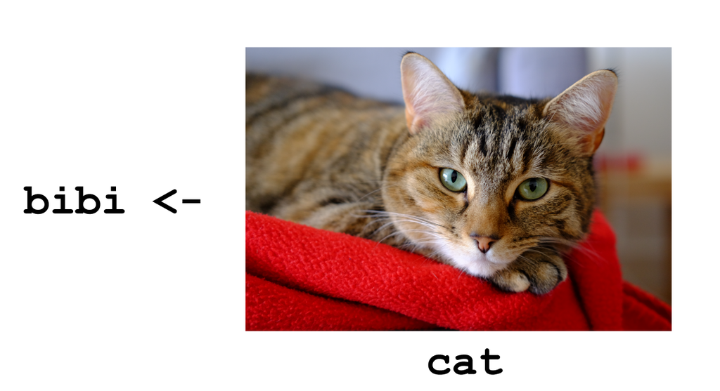

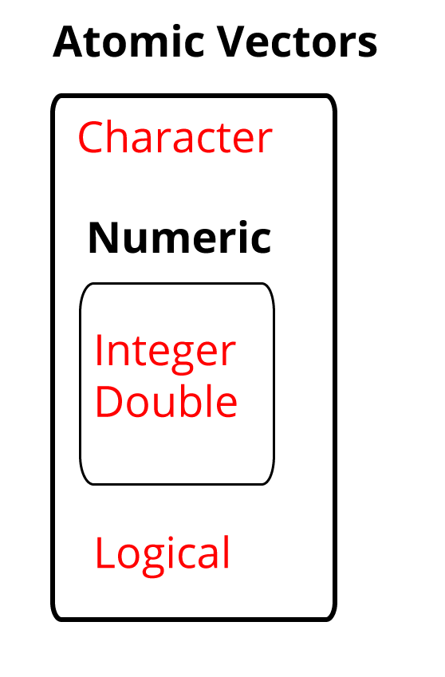

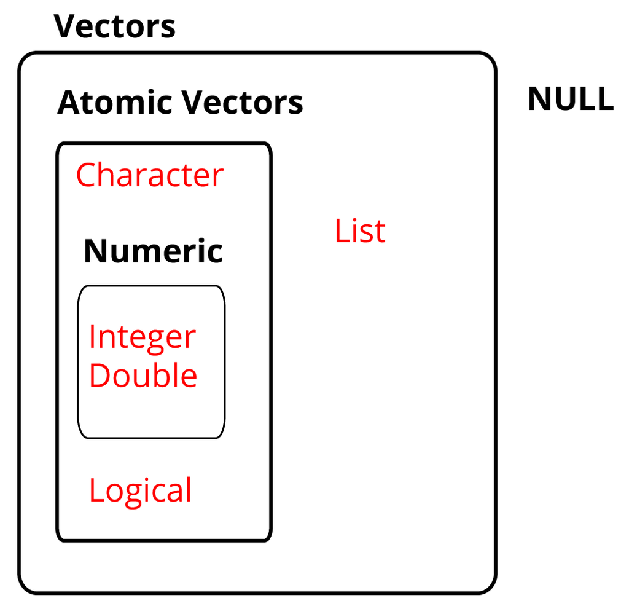

[figure not shown]

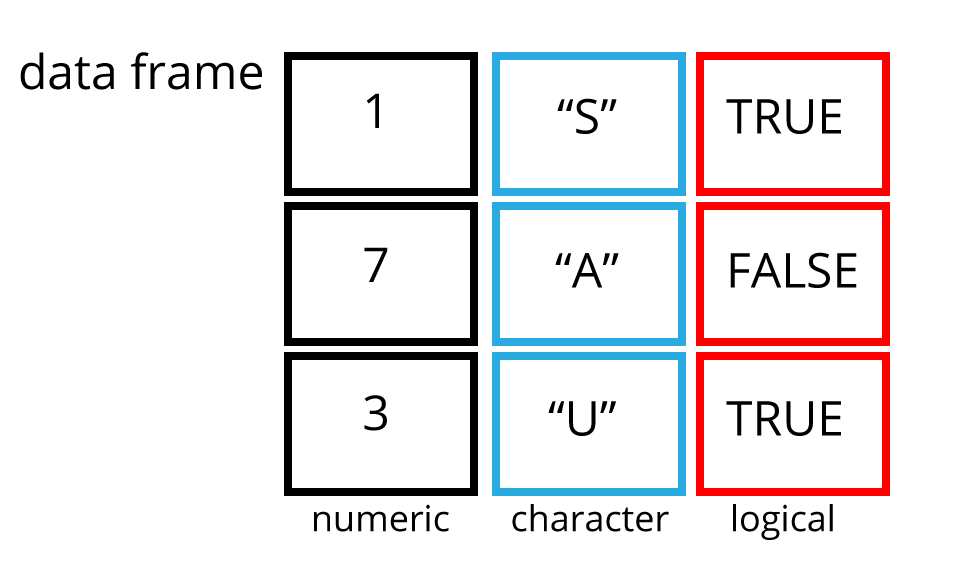

## Tidy data

1. Each variable forms a column
2. Each observation forms a row
3. Each observational unit forms a table

## dplyr::filter()

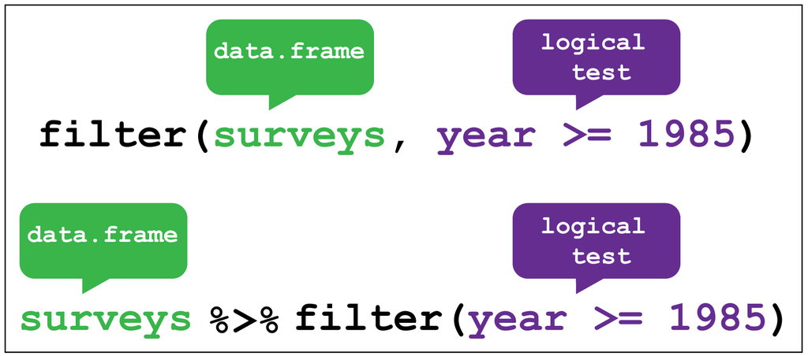

## dplyr::select()

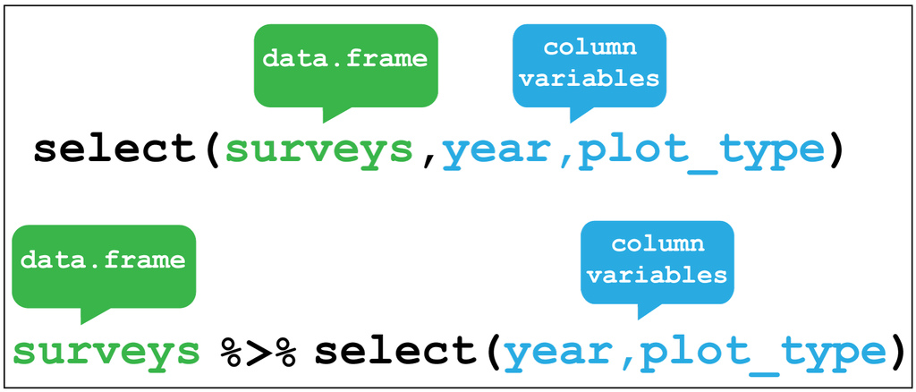

## dplyr::mutate()

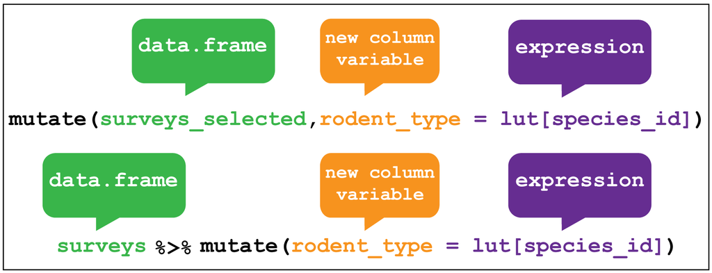

## dplyr::summarise

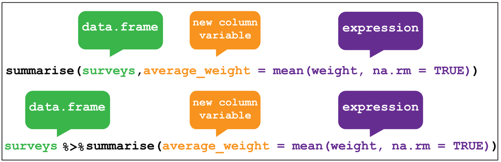

## Functions

Name,body and set of arguments

```r
# Roll two dice function
roll <- function(){
  die <- 1:6
  dice <- sample(die, size = 2, replace = TRUE)
  sum(dice)
}
```

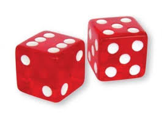

## Functions

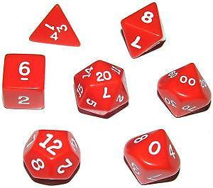

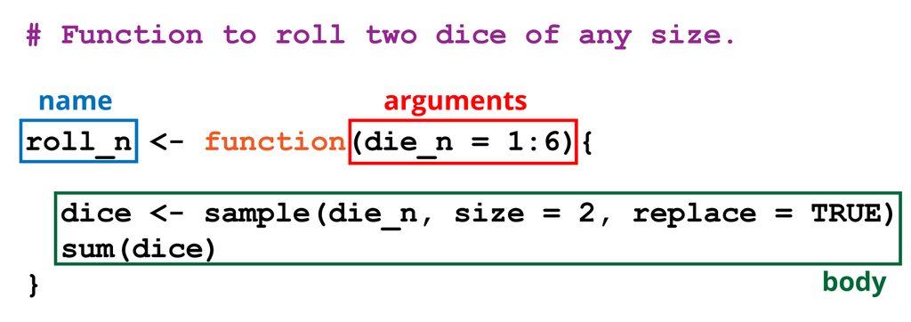

## GDP calculator

```r
# Takes a dataset and multiplies the population column
# with the GDP per capita column.
calcGDP <- function(dat, yr=NULL, ctry=NULL) {
  # Is there a year argument?
  if(!is.null(yr)) {
   dat <- dat %>% filter(year == yr)
  }
  # Is there a country argument?
  if (!is.null(ctry)) {
   dat <- dat %>% filter(country == ctry)
  }
  # Create new GDP column
  new <- dat %>% mutate(gdp = pop * gdpPercap)
  return(new)
}
```

## Further resources

- [R4DS](http://r4ds.had.co.nz/)
- [Happy Git and R](http://happygitwithr.com/)
- [Working with Spreadsheets](https://peerj.com/preprints/3183/)
- [Naming things](https://speakerdeck.com/jennybc/how-to-name-files)

## R people to follow

- Hadley Wickham @hadleywickham
- Garrett Grolemund @StatGarrett
- Jenny Bryan @JennyBryan
- Mara Averick @datandme
- Thomas Lin Pedersen @thomasp85
- Julia Silge @juliasilge
- David Robinson @drob
- Maëlle Salmon @ma_salmon
- Jesse Mostipak @kierisi